# 61070297_thanadol

```python
import urllib
import urllib.request
import json
from pandas.io.json import json_normalize
import pandas as pd
import numpy as np
import matplotlib.pyplot as plt
%matplotlib inline
!pip install folium
import folium
from IPython.display import display
```

## ทำการเลือก API

- API จัดเตรียมโดย: https://data.police.uk/docs/method/crime-street/
- โดยเฉพาะ API : ระดับการเกิดอาชญากรรมบนท้องถนนที่ประเทศอังกฤษเดือนกรกฎาคม ปีพ.ศ.2020 (JSON) https://data.police.uk/api/crimes-street/all-crime?lat=52.629729&lng=-1.131592&date=2020-07
- API สามารถใช้ได้ฟรี
- Support Email Address: feedback@data.police.uk

## เรียกดึงข้อมูล API

```python
#Link:URL file Json
url = "https://data.police.uk/api/crimes-street/all-crime?lat=52.629729&lng=-1.131592&date=2020-07" #ทำการฟิลเตอร์เลือกละติจูดที่52.62972และลองติจูดที่-1.131592 เดือนกรกฎาคมปี2020
response = urllib.request.urlopen(url)
#อ่านไฟล์๋Json
raw_json = response .read()
#แยกวิเคราะห์ JSON โดยแปลงจากสตริงเป็นโครงสร้างข้อมูล Python และเก็บอยู่ใน data
data = json.loads(raw_json)
data
```

[output not shown]

[output cut: 11544 more lines]

[output not shown]

```python
#ใช้ json_normalize ใน Pandas เพื่อสร้าง Data Frame ของข้อมูล JSON
df = json_normalize(data)
```

## ข้อมูลระดับการเกิดอาชญากรรมบนท้องถนนที่ประเทศอังกฤษเดือนกรกฎาคมปีพ.ศ.2020

- Dataframe มีตัวแปรดังนี้
  1. category = ประเภทอาชญากรรม
  2. location_type = ประเภทของสถานที่ตำรวจทั้ง Force หรือ BTP,Force ระบุตำแหน่งกองกำลังตำรวจปกติ ,BTP กองกำลังตำรวจแห่งชาติสำหรับรถไฟ สถานที่ BTP อยู่ในขอบเขตกองกำลังตำรวจปกติ
  3. context = ข้อมูลเพิ่มเติมเกี่ยวกับอาชญากรรม (ถ้ามี)
  4. id = รหัสของอาชญากรรม รหัสนี้เกี่ยวข้องกับ API เท่านั้นไม่ใช่ตัวระบุตำรวจ
  5. month = เดือนปีแห่งอาชญากรรม
  6. location.latitude = Latitude
  7. location.longitude = Longitude
  8. location.street.id = รหัสระบุเฉพาะสำหรับสถานที่
  9. location.street.name = ชื่อสถานที่นี่เป็นเพียงการประมาณว่าอาชญากรรมเกิดขึ้นที่ใด
  10. outcome_status = สถานะของผลการบันทึกล่าสุดของอาชญากรรม
  11. persistent_id = ตัวระบุเฉพาะ 64 อักขระสำหรับอาชญากรรมนั้น
  12. outcome_status.category = สถานะของผลการบันทึกล่าสุดของอาชญากรรม
  13. outcome_status.date = วันที่ผลการบันทึกสถานะล่าสุด
  14. location_subtype = สำหรับสถานที่ BTP ประเภทของสถานที่ที่บันทึกอาชญากรรมนี้

```python
df #แสดงข้อมูลใน Dataframe
```

|  | category | location_type | context | outcome_status | persistent_id | id | location_subtype | month | location.latitude | location.street.id | location.street.name | location.longitude | outcome_status.category | outcome_status.date |
| --- | --- | --- | --- | --- | --- | --- | --- | --- | --- | --- | --- | --- | --- | --- |
| 0 | anti-social-behaviour | Force |  | NaN |  | 85258564 |  | 2020-07 | 52.627744 | 883202 | On or near Mandora Lane | -1.118922 | NaN | NaN |
| 1 | anti-social-behaviour | Force |  | NaN |  | 85258574 |  | 2020-07 | 52.629909 | 883345 | On or near Marquis Street | -1.132073 | NaN | NaN |
| 2 | anti-social-behaviour | Force |  | NaN |  | 85258590 |  | 2020-07 | 52.642857 | 884332 | On or near Calgary Road | -1.125003 | NaN | NaN |
| 3 | anti-social-behaviour | Force |  | NaN |  | 85258593 |  | 2020-07 | 52.627470 | 883260 | On or near Princess Road East | -1.124409 | NaN | NaN |
| 4 | anti-social-behaviour | Force |  | NaN |  | 85259287 |  | 2020-07 | 52.637327 | 883382 | On or near Camden Street | -1.127374 | NaN | NaN |
| ... | ... | ... | ... | ... | ... | ... | ... | ... | ... | ... | ... | ... | ... | ... |
| 1097 | other-crime | Force |  | NaN | f5b7c056c2b17571520d40309765c85766d824044dd6e9... | 85265170 |  | 2020-07 | 52.625777 | 882372 | On or near Further/higher Educational Building | -1.125181 | Under investigation | 2020-07 |
| 1098 | other-crime | Force |  | NaN | 6cfd0c6cb73688a872db33ecdb05de17c02a703e17cad7... | 85262079 |  | 2020-07 | 52.627112 | 882209 | On or near Narborough Road | -1.150477 | Unable to prosecute suspect | 2020-07 |
| 1099 | other-crime | Force |  | NaN | 520fa25027db8439da587f8674bb38b9a04df5db124213... | 85261664 |  | 2020-07 | 52.615943 | 882342 | On or near Euston Street | -1.132600 | Under investigation | 2020-07 |
| 1100 | other-crime | Force |  | NaN | 7076eaafb9cfbd90bd140a59245905c0b4522e2c1982fd... | 85265197 |  | 2020-07 | 52.625777 | 882372 | On or near Further/higher Educational Building | -1.125181 | Under investigation | 2020-07 |
| 1101 | other-crime | Force |  | NaN | be71c292f74a575f9752cac6091df58c7e72db5ba53223... | 85263144 |  | 2020-07 | 52.627692 | 883257 | On or near Prison | -1.132545 | Under investigation | 2020-07 |

1102 rows × 14 columns

### ก่อนปรับปรุงแต่งข้อมูล

```python
df.to_csv("before_clean_Data.csv") #Export ข้อมูลDataFrameอยู่ในรูปแบบไฟล์.csv
print(df)
```

```
                   category location_type context  outcome_status  \
0     anti-social-behaviour         Force                     NaN
1     anti-social-behaviour         Force                     NaN
2     anti-social-behaviour         Force                     NaN
3     anti-social-behaviour         Force                     NaN
4     anti-social-behaviour         Force                     NaN
...                     ...           ...     ...             ...
1097            other-crime         Force                     NaN
1098            other-crime         Force                     NaN
1099            other-crime         Force                     NaN
1100            other-crime         Force                     NaN
1101            other-crime         Force                     NaN

                                          persistent_id        id  \
0                                                        85258564
```

[output cut: 51 more lines]

### แสดงจำนวนแถวของข้อมูล Missing value,Data typeของแต่ละคอัมน์

```python
df.info()
```

```
<class 'pandas.core.frame.DataFrame'>
RangeIndex: 1102 entries, 0 to 1101
Data columns (total 14 columns):
 #   Column                   Non-Null Count  Dtype
---  ------                   --------------  -----
 0   category                 1102 non-null   object
 1   location_type            1102 non-null   object
 2   context                  1102 non-null   object
 3   outcome_status           0 non-null      float64
 4   persistent_id            1102 non-null   object
 5   id                       1102 non-null   int64
 6   location_subtype         1102 non-null   object
 7   month                    1102 non-null   object
 8   location.latitude        1102 non-null   object
 9   location.street.id       1102 non-null   int64
 10  location.street.name     1102 non-null   object
 11  location.longitude       1102 non-null   object
 12  outcome_status.category  934 non-null    object
 13  outcome_status.date      934 non-null    object
dtypes: float64(1), int64(2), object(11)
memory usage: 120.7+ KB
```

### ตรวจสอบพบว่ามีค่า NaN

- คอลัมน์
  - outcome_status
  - outcome_status.category
  - outcome_status.date

```python
df.isnull().sum() #ตรวจสอบจำนวนค่าNaNของแต่ละคอลัมน์
```

```
category                      0
location_type                 0
context                       0
outcome_status             1102
persistent_id                 0
id                            0
location_subtype              0
month                         0
location.latitude             0
location.street.id            0
location.street.name          0
location.longitude            0
outcome_status.category     168
outcome_status.date         168
dtype: int64
```

### แสดงจำนวนประเภทอาชญากรรมแต่ละประเภท

```python
df["category"].value_counts() #เช็คจำนวนประเภทอาชญากรรมในระดับถนน
```

```
violent-crime            365
anti-social-behaviour    168
public-order             134
criminal-damage-arson     84
other-theft               61
burglary                  53
shoplifting               53
drugs                     52
vehicle-crime             37
bicycle-theft             27
possession-of-weapons     22
robbery                   19
other-crime               14
theft-from-the-person     13
Name: category, dtype: int64
```

### แสดงจำนวนชื่อสถานที่หรือถนนที่เกิดอาชญากรรม

```python
 df["location.street.name"].value_counts() #แสดงจำนวนสถานที่หรือชื่อถนนที่เกิดเหตุ
```

```
On or near Supermarket                  42
On or near Petrol Station               37
On or near Parking Area                 27
On or near Leicester Royal Infirmiry    21
On or near Euston Street                20
                                        ..
On or near Arnold Street                 1
On or near Tudor Close                   1
On or near St Stephens Road              1
On or near Tennyson Street               1
On or near Fox Street                    1
Name: location.street.name, Length: 295, dtype: int64
```

### แสดงสถานะแต่ละประเภทอาชญากรรม

- มีค่า NaN อยู่จำนวน168ค่า

```python
 df["outcome_status.category"].value_counts() #จำนวนผลการบันทึล่่าสุดของแต่ละประเภทอาชญากรรม
```

```
Investigation complete; no suspect identified          306
Unable to prosecute suspect                            292
Under investigation                                    153
Awaiting court outcome                                  74
Local resolution                                        46
Further investigation is not in the public interest     24
Formal action is not in the public interest             17
Action to be taken by another organisation               9
Offender given a caution                                 7
Further action is not in the public interest             3
Suspect charged as part of another case                  3
Name: outcome_status.category, dtype: int64
```

### แสดงประเภทของสถานที่ตำรวจทั้ง Force หรือ BTP

- Force ระบุตำแหน่งกองกำลังตำรวจปกติ
- BTP กองกำลังตำรวจแห่งชาติสำหรับรถไฟ สถานที่ BTP อยู่ในขอบเขตกองกำลังตำรวจปกติ

```python
 df["location_type"].value_counts() #แสดงจำนวนประเภทของสถานที่ตำรวจ
```

```
Force    1099
BTP         3
Name: location_type, dtype: int64
```

### แสดงจำนวนข้อมูลแถวที่ซ้ำกันใน Dataframe

- ไม่มีจำนวนแถวข้อมูลที่ซ้ำกัน

```python
df.duplicated()
len(df[df.duplicated(keep = False)]) #เช็คว่ามีจำนวนแถวที่ซ้ำกันทั้งหมดเท่าไหร่่
```

```
0
```

### ลบคอลัมน์ที่ไม่ได้ใช้

1. context
2. outcome_status
3. persistent_id
4. location_subtype
5. outcome_status.date

```python
df.drop(["context","outcome_status","persistent_id","location_subtype","outcome_status.date"],axis= 1, inplace=True) #ใช้คำสั่งดร็อปคอลัมน์ที่ไม่ได้ใช้ออก
```

```python
df #แสดงข้อมูลใน Dataframe จาก14คอลัมน์ จะเหลือ9คอลัมน์เพราะดร็อปคอลัมน์ที่ไม่ได้ใช้ออกไปแล้ว
```

|  | category | location_type | id | month | location.latitude | location.street.id | location.street.name | location.longitude | outcome_status.category |
| --- | --- | --- | --- | --- | --- | --- | --- | --- | --- |
| 0 | anti-social-behaviour | Force | 85258564 | 2020-07 | 52.627744 | 883202 | On or near Mandora Lane | -1.118922 | NaN |
| 1 | anti-social-behaviour | Force | 85258574 | 2020-07 | 52.629909 | 883345 | On or near Marquis Street | -1.132073 | NaN |
| 2 | anti-social-behaviour | Force | 85258590 | 2020-07 | 52.642857 | 884332 | On or near Calgary Road | -1.125003 | NaN |
| 3 | anti-social-behaviour | Force | 85258593 | 2020-07 | 52.627470 | 883260 | On or near Princess Road East | -1.124409 | NaN |
| 4 | anti-social-behaviour | Force | 85259287 | 2020-07 | 52.637327 | 883382 | On or near Camden Street | -1.127374 | NaN |
| ... | ... | ... | ... | ... | ... | ... | ... | ... | ... |
| 1097 | other-crime | Force | 85265170 | 2020-07 | 52.625777 | 882372 | On or near Further/higher Educational Building | -1.125181 | Under investigation |
| 1098 | other-crime | Force | 85262079 | 2020-07 | 52.627112 | 882209 | On or near Narborough Road | -1.150477 | Unable to prosecute suspect |
| 1099 | other-crime | Force | 85261664 | 2020-07 | 52.615943 | 882342 | On or near Euston Street | -1.132600 | Under investigation |
| 1100 | other-crime | Force | 85265197 | 2020-07 | 52.625777 | 882372 | On or near Further/higher Educational Building | -1.125181 | Under investigation |
| 1101 | other-crime | Force | 85263144 | 2020-07 | 52.627692 | 883257 | On or near Prison | -1.132545 | Under investigation |

1102 rows × 9 columns

### เนื่องจากบางคอลัมน์ outcome_status.category เป็นค่า NaN

- กรณีไม่มีคำอธิบายสถานะของประเภทอาชญากรรม
  - แทนที่จากค่า NaN เป็นข้อความ The value could't determined

```python
df["outcome_status.category"].fillna("The value could't determined",inplace = True) #แทนที่ค่าNan ด้วยข้อความThe value could't determined
df
```

|  | category | location_type | id | month | location.latitude | location.street.id | location.street.name | location.longitude | outcome_status.category |
| --- | --- | --- | --- | --- | --- | --- | --- | --- | --- |
| 0 | anti-social-behaviour | Force | 85258564 | 2020-07 | 52.627744 | 883202 | On or near Mandora Lane | -1.118922 | The value could't determined |
| 1 | anti-social-behaviour | Force | 85258574 | 2020-07 | 52.629909 | 883345 | On or near Marquis Street | -1.132073 | The value could't determined |
| 2 | anti-social-behaviour | Force | 85258590 | 2020-07 | 52.642857 | 884332 | On or near Calgary Road | -1.125003 | The value could't determined |
| 3 | anti-social-behaviour | Force | 85258593 | 2020-07 | 52.627470 | 883260 | On or near Princess Road East | -1.124409 | The value could't determined |
| 4 | anti-social-behaviour | Force | 85259287 | 2020-07 | 52.637327 | 883382 | On or near Camden Street | -1.127374 | The value could't determined |
| ... | ... | ... | ... | ... | ... | ... | ... | ... | ... |
| 1097 | other-crime | Force | 85265170 | 2020-07 | 52.625777 | 882372 | On or near Further/higher Educational Building | -1.125181 | Under investigation |
| 1098 | other-crime | Force | 85262079 | 2020-07 | 52.627112 | 882209 | On or near Narborough Road | -1.150477 | Unable to prosecute suspect |
| 1099 | other-crime | Force | 85261664 | 2020-07 | 52.615943 | 882342 | On or near Euston Street | -1.132600 | Under investigation |
| 1100 | other-crime | Force | 85265197 | 2020-07 | 52.625777 | 882372 | On or near Further/higher Educational Building | -1.125181 | Under investigation |
| 1101 | other-crime | Force | 85263144 | 2020-07 | 52.627692 | 883257 | On or near Prison | -1.132545 | Under investigation |

1102 rows × 9 columns

### เปลี่ยนชื่อคอลัมน์ให้อ่านง่ายขึ้น

```python
df_2 = df.rename(columns = {"id":"ID","category":"Category",
                           "location_type":"Location_type",
                            "month": "Month",
                            "location.street.id":"Street_id",
                           "location.street.name":"Location_Street_name",
                            "location.latitude":"Latitude",
                           "location.longitude":"Longitude",
                          "outcome_status.category":"Status_category"}) #ใช้คำสั่ง.renameเปลี่ยนชื่อคอลัมน์
```

```python
df_2
```

|  | Category | Location_type | ID | Month | Latitude | Street_id | Location_Street_name | Longitude | Status_category |
| --- | --- | --- | --- | --- | --- | --- | --- | --- | --- |
| 0 | anti-social-behaviour | Force | 85258564 | 2020-07 | 52.627744 | 883202 | On or near Mandora Lane | -1.118922 | The value could't determined |
| 1 | anti-social-behaviour | Force | 85258574 | 2020-07 | 52.629909 | 883345 | On or near Marquis Street | -1.132073 | The value could't determined |
| 2 | anti-social-behaviour | Force | 85258590 | 2020-07 | 52.642857 | 884332 | On or near Calgary Road | -1.125003 | The value could't determined |
| 3 | anti-social-behaviour | Force | 85258593 | 2020-07 | 52.627470 | 883260 | On or near Princess Road East | -1.124409 | The value could't determined |
| 4 | anti-social-behaviour | Force | 85259287 | 2020-07 | 52.637327 | 883382 | On or near Camden Street | -1.127374 | The value could't determined |
| ... | ... | ... | ... | ... | ... | ... | ... | ... | ... |
| 1097 | other-crime | Force | 85265170 | 2020-07 | 52.625777 | 882372 | On or near Further/higher Educational Building | -1.125181 | Under investigation |
| 1098 | other-crime | Force | 85262079 | 2020-07 | 52.627112 | 882209 | On or near Narborough Road | -1.150477 | Unable to prosecute suspect |
| 1099 | other-crime | Force | 85261664 | 2020-07 | 52.615943 | 882342 | On or near Euston Street | -1.132600 | Under investigation |
| 1100 | other-crime | Force | 85265197 | 2020-07 | 52.625777 | 882372 | On or near Further/higher Educational Building | -1.125181 | Under investigation |
| 1101 | other-crime | Force | 85263144 | 2020-07 | 52.627692 | 883257 | On or near Prison | -1.132545 | Under investigation |

1102 rows × 9 columns

### แสดงจำนวนข้อมูลแถวที่ซ้ำกันหลังจากเปลี่ยนค่าNan

- ลบจำนวนคอลัมน์ที่ไม่ใช้ออกพบว่าไม่มีจำนวนแถวข้อมูลที่ซ้ำกัน

```python
len(df_2[df_2.duplicated(keep = False)]) #เช็คว่ามีจำนวนแถวที่ซ้ำกันทั้งหมดเท่าไหร่
```

```
0
```

### แสดงจำนวนค่าNaNแต่ะละคอลัมน์หลังจากลบคอลัมน์ที่ไม่ใช้ออก

- แทนที่ค่าNaNที่คอลัมน์Status_category ด้วยข้อความ The value could't determined
  - ทำให้ข้อมูลในDataframeไม่มีค่าNan

```python
df_2.isnull().sum() #เช็คจำนวนค่าNaNของแต่ละคอลัมน์
```

```
Category                0
Location_type           0
ID                      0
Month                   0
Latitude                0
Street_id               0
Location_Street_name    0
Longitude               0
Status_category         0
dtype: int64
```

### หลังจากปรุงแต่งข้อมูลเสร็จ

- เซฟข้อมูลใน Dataframe เป็นไฟล์CSV ชื่อไฟล์ After_clean_Data

```python
df_2.to_csv("After_clean_Data.csv") #Export Dataframe to file.csv
print(df_2)
```

```
                   Category Location_type        ID    Month   Latitude  \
0     anti-social-behaviour         Force  85258564  2020-07  52.627744
1     anti-social-behaviour         Force  85258574  2020-07  52.629909
2     anti-social-behaviour         Force  85258590  2020-07  52.642857
3     anti-social-behaviour         Force  85258593  2020-07  52.627470
4     anti-social-behaviour         Force  85259287  2020-07  52.637327
...                     ...           ...       ...      ...        ...
1097            other-crime         Force  85265170  2020-07  52.625777
1098            other-crime         Force  85262079  2020-07  52.627112
1099            other-crime         Force  85261664  2020-07  52.615943
1100            other-crime         Force  85265197  2020-07  52.625777
1101            other-crime         Force  85263144  2020-07  52.627692

      Street_id                            Location_Street_name  Longitude  \
0        883202                         On or near Mandora Lane  -1.118922
```

[output cut: 25 more lines]

### แสดงจำนวนแต่ละประเภทของอาชญากรรม

```python
count_category = df_2["Category"].value_counts() #นับจำนวนประเภทของอาชญากรรมในคอลัมน์ Category
count_category
```

```
violent-crime            365
anti-social-behaviour    168
public-order             134
criminal-damage-arson     84
other-theft               61
burglary                  53
shoplifting               53
drugs                     52
vehicle-crime             37
bicycle-theft             27
possession-of-weapons     22
robbery                   19
other-crime               14
theft-from-the-person     13
Name: Category, dtype: int64
```

## แสดงกราฟ bar chart ประเภทระดับการเกิดอาชญากรรมทั้งหมดบนท้องถนนที่ประเทศอังกฤษเดือนกรกฎาคม ปีพ.ศ.2020

- จำนวนที่เกิดอาชญากรรมมากที่สุดคืออาชญากรรมประเภท violent-crime 365 ครั้ง
- จำนวนที่เกิดอาชญากรรมน้อยที่สุดคืออาชญากรรมระเภท theft-from-the-person 13 ครั้ง

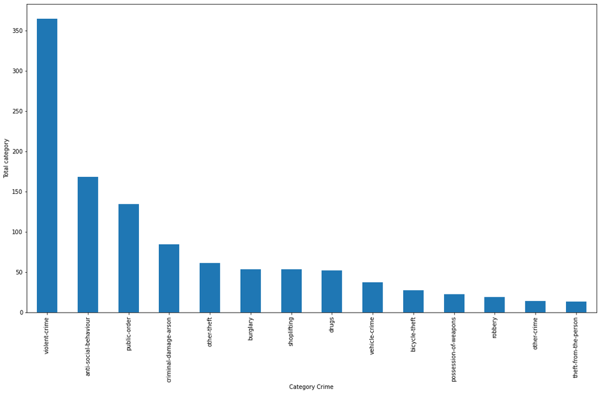

```python
my_plot = count_category.plot(kind="bar",figsize=(18, 10)) #นำcount_categoryมาพล็อตกราฟประเภท bar chart
my_plot.set_xlabel("Category Crime") #กำหนดชื่อตัวแปรแกน x
my_plot.set_ylabel("Total category") #กำหนดชื่อตัวแปรแกน Y
```

### เนื่องจากอาชญากรรมประเภท violent-crime อาชญากรรมรุนแรงเกิดขึ้นเยอะที่สุด และดูว่าอาชญากรรมประเภทviolent-crime เกิดขึ้นที่สถานที่ไหนมากที่สุด10อันดับ

```python
lomax_cat = df_2[df_2['Category'] == 'violent-crime']['Location_Street_name'].value_counts().head(10) #เลือกcatrgory ประเภทviolent-crime และดูว่าเกิดอาชญากรรมที่ไหนบ้าง โชว์10อันดับที่มากที่สุด
lomax_cat
```

```
On or near Leicester Royal Infirmiry              14
On or near Supermarket                            10
On or near Prison                                  9
On or near Granby Street                           9
On or near Parking Area                            9
On or near Petrol Station                          9
On or near Nightclub                               9
On or near Cromford Street                         7
On or near Further/higher Educational Building     6
On or near The Oval                                6
Name: Location_Street_name, dtype: int64
```

## แสดงกราฟ bar chart ของสถานที่ที่เกิดอาชญากรรมประเภท violent-crime มากที่สุด 10 อันดับ บนท้องถนนที่ประเทศอังกฤษเดือนกรกฎาคม ปี พ.ศ. 2020

- สถานที่ที่เกิดอาชญากรรมมากที่สุดใน 10 อันดับคือ On or near Leicester Royal Infirmiry 14 ครั้ง
- สถานที่ที่เกิดอาชญากรรมน้อยที่สุดใน 10 อันดับคือ On or near The Oval,On or near Further/higher Educational Building 6 ครั้ง

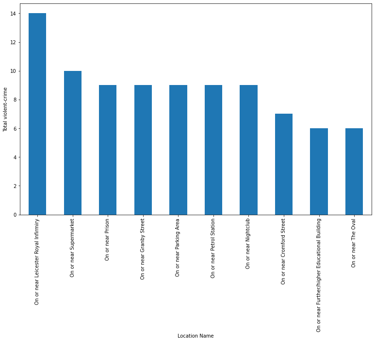

```python
my_plot = lomax_cat.head(10).plot(kind="bar",figsize=(13, 8)) #นำสถานที่เกิดอาญชากรรมประเภทviolent-crimeมากที่สุด10อันดับมาพล็อตกราฟประเภท bar chart
my_plot.set_xlabel("Location Name") #กำหนดชื่อตัวแปรแกน x
my_plot.set_ylabel("Total violent-crime") #กำหนดชื่อตัวแปรแกน y
```

### แสดงจำนวนสถานะของอาชญากรรม

```python
count_status =  df_2["Status_category"].value_counts() #นับจำนวนสถานะอาชญากรรม
count_status
```

```
Investigation complete; no suspect identified          306
Unable to prosecute suspect                            292
The value could't determined                           168
Under investigation                                    153
Awaiting court outcome                                  74
Local resolution                                        46
Further investigation is not in the public interest     24
Formal action is not in the public interest             17
Action to be taken by another organisation               9
Offender given a caution                                 7
Further action is not in the public interest             3
Suspect charged as part of another case                  3
Name: Status_category, dtype: int64
```

### แสดงจำนวนประเภทอาชญากรรมที่มีสถานะ Investigation complete; no suspect identified

- อาชญากรรมที่มีสถานะการสอบสวนเสร็จสมบูรณ์และไม่พบผู้ต้องสงสัย

```python
status_cat =  df_2[df_2['Status_category'] == 'Investigation complete; no suspect identified']['Category'].value_counts() #แสดงจำนวนประเภทอาชญากรรมที่มีสถานะ Investigation complete; no suspect identified
status_cat
```

```
violent-crime            56
public-order             40
criminal-damage-arson    38
shoplifting              36
other-theft              36
burglary                 31
vehicle-crime            29
bicycle-theft            24
theft-from-the-person     7
robbery                   6
possession-of-weapons     2
drugs                     1
Name: Category, dtype: int64
```

## แสดงกราฟ bar chart ประเภทอาชญากรรมที่มีสถานะการสอบสวนที่เสร็จสมบูรณ์และไม่พบผู้ต้องสงสัย

- ประเภทอาชญากรรมที่มีสถานะเสร็จสมบูรณ์เยอะที่สุดคือ violent-crime 56 ครั้ง
- ประเภทอาชญากรรมที่มีสถานะเสร็จสมบูรณ์น้อยที่สุดคือ drugs 1 ครั้ง

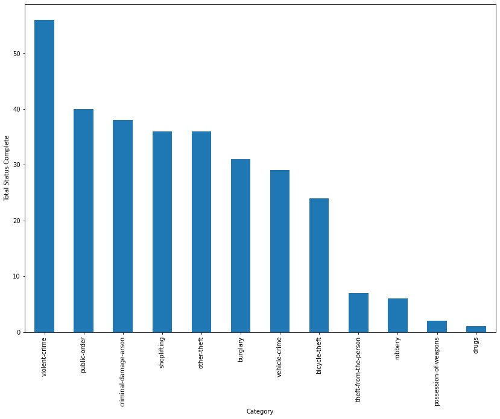

```python
my_plot = status_cat.plot(kind="bar",figsize=(14, 10)) #พล็อตกราฟ bar chart แสดงประเภทอาชญากรรมที่มีสถานะการสอบสวนที่เสร็จสมบูรณ์และไม่พบผู้ต้องสงสัย
my_plot.set_xlabel("Category") #กำหนดชื่อตัวแปรแกน x
my_plot.set_ylabel("Total Status Complete") #กำหนดชื่อตัวแปรแกน y
```

### แสดงจำนวนสถานที่ ที่เกิดอาชญากรรมมากที่สุด 10 อันดับ

```python
count_lsname = df_2["Location_Street_name"].value_counts()  #นับจำนวนสถานที่หรือถนนที่เกิดอาชญากรรม
count_lsname.head(10) #แสดงแค่10อันดับสถานที่หรือถนนที่เกิดอาชญากรรมมากที่สุด
```

```
On or near Supermarket                            42
On or near Petrol Station                         37
On or near Parking Area                           27
On or near Leicester Royal Infirmiry              21
On or near Euston Street                          20
On or near Nightclub                              19
On or near Granby Street                          15
On or near Prison                                 14
On or near Tudor Road                             14
On or near Further/higher Educational Building    14
Name: Location_Street_name, dtype: int64
```

## แสดงกราฟ bar chart สถานที่หรือถนนที่เกิดอาชญากรรมมากที่สุด10อันดับบนท้องถนนที่ประเทศอังกฤษเดือนกรกฎาคม ปี พ.ศ. 2020

- สถานที่ที่เกิดอาชญากรรมมากที่สุดใน 10 อันดับคือ On or near Supermarket 42 ครั้ง
- สถานที่ที่เกิดอาชญากรรมน้อยที่สุดใน 10 อันดับคือ On or near Further/higher Educational Building, On or near Tudor Road, On or near Prison 14 ครั้ง

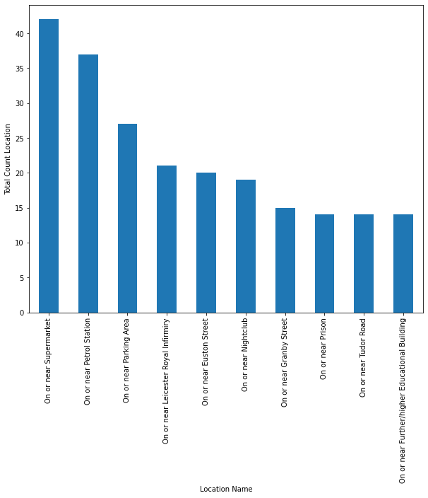

```python
my_plot = count_lsname.head(10).plot(kind="bar",figsize=(10, 8)) #นำจำนวนสถานที่ที่เกิดอาชญากรรมมากที่สุด10อันดับมาพล็อตกราฟประเภท bar chart
my_plot.set_xlabel("Location Name") #กำหนดชื่อตัวแปรแกน x
my_plot.set_ylabel("Total Count Location") #กำหนดชื่อตัวแปรแกน y
```

### เนื่องจาก On or near Supermarketเป็นสถานที่ที่เกิดอาชญากรรมเยอะที่สุด 42 ครั้ง จากกราฟด้านบน

- จึงนำมาแสดงว่าเกิดประเภทอาชญากรรมแต่ละประเภทอะไรบ้าง ที่ On or near Supermarket

```python
location_born_ct = df_2[df_2['Location_Street_name'] == 'On or near Supermarket']['Category'].value_counts() #แสดงจำนวนประเภทอาชญากรรมแต่ะประเภทที่เกิดขึ้นที่On or near Supermarket
location_born_ct
```

```
shoplifting              11
violent-crime            10
other-theft               6
anti-social-behaviour     5
public-order              4
burglary                  3
criminal-damage-arson     2
vehicle-crime             1
Name: Category, dtype: int64
```

## แสดงกราฟ bar chart จำนวนประเภทของอาชญากรรมที่เกิดขึ้นที่ On or near Supermarket บนท้องถนนที่ประเทศอังกฤษเดือนกรกฎาคม ปี พ.ศ. 2020

- ประเภทอาชญากรรมที่เกิดขึ้นมากที่สุดคือ shoplifting 11 ครั้ง
- ประเภทอาชญากรรมที่เกิดน้อยที่สุดคือvehicle-crime 1 ครั้ง

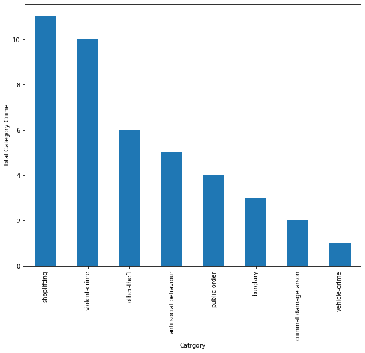

```python
my_plot = location_born_ct.plot(kind="bar",figsize=(10, 8)) #นำจำนวน location_born_ct มาพล็อตกราฟประเภท bar chart
my_plot.set_xlabel("Catrgory")  #กำหนดตัวแปรแกน x
my_plot.set_ylabel("Total Category Crime") #กำหนดตัวแปรแกน y
```

## แสดงกราฟแผนที่การเกิดอาชญากรรมที่ประเทศอังกฤษเดือนกรกฎาคม ปีพ.ศ.2020

- ระบุจุดที่เกิดเหตุอาชญากรรม
- แสดงประเภทอาชญากรรมบนท้องถนนเมื่อคลิกไปที่จุดMark

```python
mapp = folium.Map(location=[52.638452, -1.128697],zoom_start=14) #แสดงช่วงพิกััดภาพรวมของพื้นที่ในแผนที่ที่เกิดอาชญากรรมและใช้คำสั่งzoom_startซูมเข้าไปให้ใกล้ๆจุดมาร์ค
tooltip = 'Click me!'
for i in range(len(df_2)): #ทำการเข้าลูปตามจำนวนข้อมูลใน Dataframe
    #ทำการมาร์คจุดในแผนที่โดยใช้คอลัมน์Latitude,Longitudeเพื่อแสดงพิกัด และใช้คอลัมน์Categoryเมื่อนำเมาส์ไปชี้แล้วคลิกเพื่อบอกว่าแต่ละจุดที่มาร์คเป็นอาชญากรรมประเภทไหน โดยลูปวนตามจำนวนข้อมูลในDataframe
    folium.Marker([df_2['Latitude'].iloc[i], df_2['Longitude'].iloc[i]], popup=df_2['Category'].iloc[i], tooltip=tooltip).add_to(mapp)
display(mapp) #โชว์แผนที่
```

Make this Notebook Trusted to load map: File -> Trust Notebook

[interactive chart not shown]

### แสดง ratio ของแต่ละประเภทอาชญากรรม

```python
category_ratio = df_2["Category"].value_counts(normalize = True) #นำจำนวนอาชญากรรมแต่ละประเภทของคอลัมน์Categoryมาทำเป็นอัตราส่วน
category_ratio
```

```
violent-crime            0.331216
anti-social-behaviour    0.152450
public-order             0.121597
criminal-damage-arson    0.076225
other-theft              0.055354
shoplifting              0.048094
burglary                 0.048094
drugs                    0.047187
vehicle-crime            0.033575
bicycle-theft            0.024501
possession-of-weapons    0.019964
robbery                  0.017241
other-crime              0.012704
theft-from-the-person    0.011797
Name: Category, dtype: float64
```

```python
category_ratio = df_2["Category"].value_counts(normalize = True).reset_index(name="ratio") #นำจำนวนแต่ละประเภทของอาชญากรรมมาทำเป็นratio และเปลี่ยนชื่อคอลัมน์ที่เป็นindexเดิมของคอลัมน์ที่เป็นเลขอัตราเป็นชื่อratio
total_ratio = category_ratio.loc[category_ratio["ratio"]<0.05, "index"] #หาcategory_ratioแต่ละแถวที่มีค่าน้อยกว่า5%
df_2.loc[df_2["Category"].isin(total_ratio), "Category"] = "Other Offenses" #นำratioที่น้อยกว่า5%ไปเก็บรวมไว้ในตัวแปร Other Offenses
df_2["Category"].value_counts(normalize = True) #ดูratioแต่ละประเภทอาชญากรรม
```

```
violent-crime            0.331216
Other Offenses           0.263158
anti-social-behaviour    0.152450
public-order             0.121597
criminal-damage-arson    0.076225
other-theft              0.055354
Name: Category, dtype: float64
```

## แสดงกราฟ Pie chart อัตตราการเกิดอาชญากรรมของแต่ละประเภท

**โดยให้ประเภทที่มีอัตตราการเกิดน้อยกว่า5% นำไปรวมอยู่ใน Other Offenses**

- อาชญากรรมที่มีอัตราการเกิดมากที่สุดคือ violent-crime 33.12%
- อาชญากรรมที่มีอัตราการเกิดน้อยที่สุดคือ other-theft 5.54%

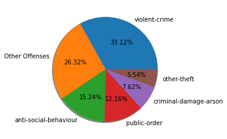

```python
pie_cat = ['violent-crime','Other Offenses',"anti-social-behaviour",'public-order ','criminal-damage-arson','other-theft'] #ประเภทอาชญากรรมต่างๆที่มีratioมากกว่า5%
ratio = [0.331216,0.263158,0.152450,0.121597,0.076225,0.055354] #rtio ของแต่ประเภทอาชญากรรม
fig1, ax1 = plt.subplots()
ax1.pie(ratio, labels=pie_cat, autopct='%1.2f%%',shadow=True) #พล็อตกราฟประเภทpie chart ใส่ชื่อประเภทอาชญากรรมและratioเป็นเลขทศนิยม2ตำแหน่ง
plt.show() #แสดงกราฟ
```

# สรุปผล

จากข้อมูลระดับการเกิดอาชญากรรมบนท้องถนนที่ประเทศอังกฤษเดือนกรกฎาคม ปีพ.ศ.2020 ที่เรานำมา ทำให้เรามองเห็นภาพรวมว่าเกิดอาชญากรรมประเภทอะไรบ้างและเกิดขึ้นที่ไหนโดยสังเกตุจากแผนที่ และทราบระดับการเกิดอาชญากรรมรุนแรงหรือviolent-crimeนั้นเกิดขึ้นเยอะที่สุด365ครั้งหรือมีอัตราการเกิด33.12% แต่มีสถานะการสอบสวนเสร็จสมบูรณ์และไม่พบผู้ต้องสงสัยแค่56ครั้งซึ่งน้อยมากทำให้เจ้าหน้าที่ต้องพยายามเพิ่มประสิทธิภาพในการสืบสวนคดีประเภทนี้ และสถานที่ที่มีการเกิดอาชญากรรมมากที่สุดคือ On or near Supermarket มีจำนวน42ครั้ง ทำให้ต้องเพิ่มระดับความปลอดภัยเพื่อพยายามระงับการเกิดเหตุอาชญารรม